```python
import pandas as pd
import plotly.express as px
import plotly.graph_objects as go
from plotly.subplots import make_subplots
import pypandoc
import matplotlib.pyplot as plt
import numpy as np
import statsmodels.api as sm
from sklearn import linear_model

import random

import matplotlib.pyplot as plt
from matplotlib import rcParams
import pandas as pd
import statsmodels.api as sm
import statsmodels.formula.api as smf
from statsmodels.nonparametric.smoothers_lowess import lowess
import numpy as np
import scipy.stats as stats

from sklearn.model_selection import train_test_split
from sklearn.metrics import confusion_matrix
from sklearn.metrics import accuracy_score
from sklearn.metrics import classification_report
from sklearn.metrics import mean_squared_error

from sklearn.linear_model import Ridge
from sklearn.model_selection import cross_val_score
from sklearn import linear_model

from sklearn.decomposition import PCA
from sklearn.model_selection import cross_val_score
from sklearn.preprocessing import StandardScaler
from sklearn.linear_model import LinearRegression
from sklearn.linear_model import LassoCV
from sklearn.linear_model import Lasso
from sklearn.linear_model import RidgeCV
```

# Lab 8.3.1 Fitting Classification Trees

```python
from sklearn import tree
from sklearn.tree import DecisionTreeClassifier
from sklearn.tree import DecisionTreeRegressor
```

```python
import graphviz
```

```python
Carseats = pd.read_csv('Carseats.csv')
```

```python
# Have to feature engineer ShelveLoc for classification tree in sklearn
Carseats['ShelveLoc_ord'] = Carseats['ShelveLoc'].apply(lambda x: 0 if x=='Bad' else (0.5 if x=='Medium' else 1))
```

```python
Carseats['Urban'] = Carseats.Urban.map(dict(Yes=1, No=0))
```

```python
Carseats['US'] = Carseats.US.map(dict(Yes=1, No=0))
```

```python
Carseats['High'] = Carseats['Sales'].apply(lambda x: 'No' if x <= 8 else 'Yes')
```

```python
carseat_input_cols = list(Carseats.columns)
carseat_input_cols.remove('ShelveLoc')
carseat_input_cols.remove('Sales')
carseat_input_cols.remove('High')
```

```python
X = Carseats[carseat_input_cols]
```

```python
y = Carseats['High']
```

```python
clf = tree.DecisionTreeClassifier()
clf = clf.fit(X,y)
```

```python
dot_data = tree.export_graphviz(clf, out_file=None,
                               feature_names=X.columns,
                               class_names=y.unique(),
                               filled=True, rounded=True,
                               special_characters=True)
graph = graphviz.Source(dot_data)
graph
```

[figure not shown]

```python
# Split into Test and Training data
X_train, X_test, y_train, y_test = train_test_split(X, y, test_size=0.25, random_state=42)
```

```python
clf = tree.DecisionTreeClassifier()
clf = clf.fit(X_train,y_train)
```

```python
test_predictions = clf.predict(X_test)
```

```python
print(classification_report(y_test,test_predictions))
```

```
              precision    recall  f1-score   support

          No       0.80      0.70      0.74        56
         Yes       0.67      0.77      0.72        44

    accuracy                           0.73       100
   macro avg       0.73      0.73      0.73       100
weighted avg       0.74      0.73      0.73       100
```

```python
accuracy_score(y_test,test_predictions)
```

```
0.73
```

```python
results = confusion_matrix(y_test, test_predictions)
```

```python
df_cm = pd.DataFrame(results, index=['No','Yes'], columns = ['No','Yes'])
df_cm
```

[output not shown]

Test Set gives an accuracy of 0.73 using the full tree.

## Cost Complexity Pruning

```python
# Cost complexity pruning
clf = tree.DecisionTreeClassifier(random_state=0)
path = clf.cost_complexity_pruning_path(X,y)
ccp_alphas, impurities = path.ccp_alphas, path.impurities
```

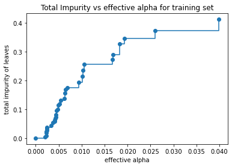

```python
fig, ax = plt.subplots()
ax.plot(ccp_alphas[:-1], impurities[:-1], marker='o', drawstyle="steps-post")
ax.set_xlabel("effective alpha")
ax.set_ylabel("total impurity of leaves")
ax.set_title("Total Impurity vs effective alpha for training set")
```

```python
clfs = []
tree_node_count = []
max_depth = []
error_rate = []
for ccp_alpha in ccp_alphas:
    clf = DecisionTreeClassifier(random_state=0, ccp_alpha=ccp_alpha)
    clf.fit(X_train, y_train)
    clfs.append(clf)
    test_predictions = clf.predict(X_test)
    error_rate.append(1-accuracy_score(y_test,test_predictions))
    tree_node_count.append(clf.tree_.node_count)
    max_depth.append(clf.tree_.max_depth)
cost_complexity_dict = {'alpha_eff':ccp_alphas,'node_count':tree_node_count, 'max_depth':max_depth, 'error_rate': error_rate}
```

## Cross validation with cost complexity pruning

```python
def run_cross_validation_on_trees(X, y, ccp_alphas, cv=5, scoring='accuracy'):
    cv_scores_list = []
    cv_scores_std = []
    cv_scores_mean = []
    accuracy_scores = []
    for ccp_alpha in ccp_alphas:
        tree_model = DecisionTreeClassifier(random_state=0, ccp_alpha=ccp_alpha)
        cv_scores = cross_val_score(tree_model, X, y, cv=cv, scoring=scoring)
        cv_scores_list.append(cv_scores)
        cv_scores_mean.append(cv_scores.mean())
        cv_scores_std.append(cv_scores.std())
        accuracy_scores.append(tree_model.fit(X, y).score(X, y))
    cv_scores_mean = np.array(cv_scores_mean)
    cv_scores_std = np.array(cv_scores_std)
    accuracy_scores = np.array(accuracy_scores)
    return cv_scores_mean, cv_scores_std, accuracy_scores
```

```python
def plot_cross_validation_on_trees(ccp_alphas, cv_scores_mean, cv_scores_std, accuracy_scores, title):
    fig, ax = plt.subplots(1,1, figsize=(15,5))
    ax.plot(ccp_alphas, cv_scores_mean, '-o', label='mean cross-validation accuracy', alpha=0.9)
#     ax.fill_between(ccp_alphas, cv_scores_mean-2*cv_scores_std, cv_scores_mean+2*cv_scores_std, alpha=0.2)
#     ylim = plt.ylim()
    ax.plot(ccp_alphas, accuracy_scores, '-*', label='train accuracy', alpha=0.9)
    ax.set_title(title, fontsize=16)
    ax.set_xlabel('effective alpha', fontsize=14)
    ax.set_ylabel('Accuracy', fontsize=14)
#     ax.set_ylim(ylim)
#     ax.set_xticks(ccp_alphas)
    ax.legend()
```

```python
sm_cv_scores_mean, sm_cv_scores_std, sm_accuracy_scores = run_cross_validation_on_trees(X_train, y_train, ccp_alphas)
```

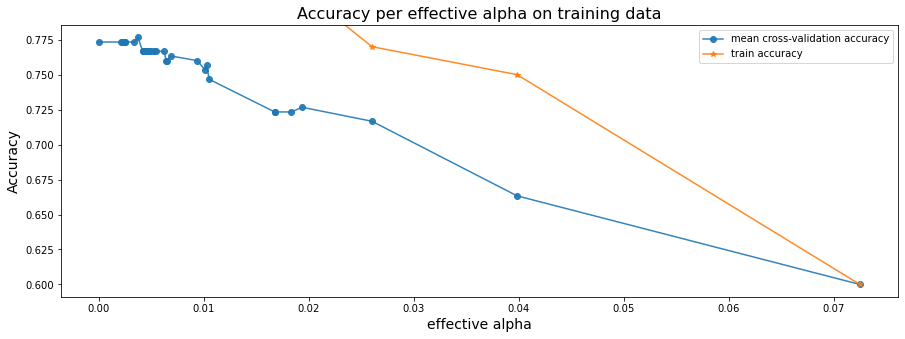

```python
plot_cross_validation_on_trees(ccp_alphas, sm_cv_scores_mean, sm_cv_scores_std, sm_accuracy_scores,
                               'Accuracy per effective alpha on training data')
```

```python
best_score_loc = np.where(sm_cv_scores_mean == np.amax(sm_cv_scores_mean))[0][0]
best_score_loc
```

```
9
```

```python
cv_alpha = ccp_alphas[best_score_loc]
cv_alpha
```

```
0.003703703703703704
```

```python
clf = DecisionTreeClassifier(random_state=0, ccp_alpha=cv_alpha)
clf.fit(X_train, y_train)
```

```
DecisionTreeClassifier(ccp_alpha=0.003703703703703704, random_state=0)
```

```python
clf.tree_.max_depth
```

```
9
```

```python
test_predictions = clf.predict(X_test)
```

```python
print(classification_report(y_test,test_predictions))
```

```
              precision    recall  f1-score   support

          No       0.82      0.71      0.76        56
         Yes       0.69      0.80      0.74        44

    accuracy                           0.75       100
   macro avg       0.75      0.75      0.75       100
weighted avg       0.76      0.75      0.75       100
```

```python
accuracy_score(y_test,test_predictions)
```

```
0.75
```

```python
results = confusion_matrix(y_test, test_predictions)
```

```python
df_cm = pd.DataFrame(results, index=['No','Yes'], columns = ['No','Yes'])
df_cm
```

|  | No | Yes |
| --- | --- | --- |
| No | 40 | 16 |
| Yes | 9 | 35 |

# Lab 8.3.2 Fitting Regression Trees

```python
Boston = pd.read_csv("Boston.csv", index_col=0)
```

```python
Boston.head()
```

|  | crim | zn | indus | chas | nox | rm | age | dis | rad | tax | ptratio | black | lstat | medv |
| --- | --- | --- | --- | --- | --- | --- | --- | --- | --- | --- | --- | --- | --- | --- |
| 1 | 0.00632 | 18.0 | 2.31 | 0 | 0.538 | 6.575 | 65.2 | 4.0900 | 1 | 296 | 15.3 | 396.90 | 4.98 | 24.0 |
| 2 | 0.02731 | 0.0 | 7.07 | 0 | 0.469 | 6.421 | 78.9 | 4.9671 | 2 | 242 | 17.8 | 396.90 | 9.14 | 21.6 |
| 3 | 0.02729 | 0.0 | 7.07 | 0 | 0.469 | 7.185 | 61.1 | 4.9671 | 2 | 242 | 17.8 | 392.83 | 4.03 | 34.7 |
| 4 | 0.03237 | 0.0 | 2.18 | 0 | 0.458 | 6.998 | 45.8 | 6.0622 | 3 | 222 | 18.7 | 394.63 | 2.94 | 33.4 |
| 5 | 0.06905 | 0.0 | 2.18 | 0 | 0.458 | 7.147 | 54.2 | 6.0622 | 3 | 222 | 18.7 | 396.90 | 5.33 | 36.2 |

```python
boston_input_cols = list(Boston.columns)
boston_input_cols.remove('medv')
```

```python
X = Boston[boston_input_cols]
y = Boston['medv']
```

```python
# Split into Test and Training data
X_train, X_test, y_train, y_test = train_test_split(X, y, test_size=0.5, random_state=42)
```

```python
clf = DecisionTreeRegressor()
clf = clf.fit(X_train, y_train)
```

```python
test_predictions = clf.predict(X_test)
```

```python
mean_squared_error(y_test,test_predictions)
```

```
27.476086956521737
```

```python
dot_data = tree.export_graphviz(clf, out_file=None,
                               feature_names=X.columns,
                               class_names=y.unique(),
                               filled=True, rounded=True,
                               special_characters=True)
graph = graphviz.Source(dot_data)
graph
```

[figure not shown]

```python
clf.tree_.max_depth
```

```
20
```

```python
path = clf.cost_complexity_pruning_path(X_train,y_train)
ccp_alphas, impurities = path.ccp_alphas, path.impurities
```

```python
clfs = []
tree_node_count = []
max_depth = []
mse = []
for ccp_alpha in ccp_alphas:
    clf = DecisionTreeRegressor(random_state=0, ccp_alpha=ccp_alpha)
    clf.fit(X_train, y_train)
    clfs.append(clf)
    test_predictions = clf.predict(X_test)
    mse.append(mean_squared_error(y_test,test_predictions))
    tree_node_count.append(clf.tree_.node_count)
    max_depth.append(clf.tree_.max_depth)
cost_complexity_dict = {'alpha_eff':ccp_alphas,'node_count':tree_node_count, 'max_depth':max_depth, 'mse': mse}
```

```python
cost_complexity_df = pd.DataFrame(cost_complexity_dict)
cost_complexity_df
```

|  | alpha_eff | node_count | max_depth | mse |
| --- | --- | --- | --- | --- |
| 0 | 0.000000e+00 | 479 | 20 | 27.791225 |
| 1 | 5.616939e-17 | 479 | 20 | 27.791225 |
| 2 | 1.348065e-15 | 475 | 20 | 27.791225 |
| 3 | 1.797420e-15 | 471 | 20 | 27.791225 |
| 4 | 2.696131e-15 | 471 | 20 | 27.791225 |
| ... | ... | ... | ... | ... |
| 228 | 3.215866e+00 | 9 | 3 | 26.420013 |
| 229 | 3.823788e+00 | 9 | 3 | 26.420013 |
| 230 | 5.822861e+00 | 7 | 2 | 29.616572 |
| 231 | 1.465860e+01 | 3 | 1 | 50.907505 |
| 232 | 4.489231e+01 | 1 | 0 | 81.316561 |

233 rows × 4 columns

```python
# Figure out alpha values for each max_depth
alphas = []
for depth in cost_complexity_df.max_depth.unique():
    df = cost_complexity_df.loc[cost_complexity_df['max_depth'] == depth]
    min_id = df['mse'].idxmin()
    alpha_eff = df.loc[min_id]['alpha_eff']
    alphas.append(alpha_eff)
if not alphas.count(0):
    alphas.insert(0,0)
```

```python
alphas
```

```
[0,
 7.90513834000363e-05,
 7.905138340183373e-05,
 0.003201581027667769,
 0.019927536231891547,
 0.02371541501975835,
 0.03320816864294846,
 0.05093214756258433,
 0.08352343308865279,
 0.08632608695652003,
 0.1339029399149142,
 0.23753328479301583,
 0.3409793250228046,
 2.7517275252745614,
 3.2158663689809717,
 5.822861233550194,
 14.6585982231659,
 44.89231353352508]
```

## Cross Validation for pruning

```python
def run_cross_validation_on_regression_trees(X, y, ccp_alphas, cv=5, scoring='neg_mean_squared_error'):
    cv_scores_list = []
    cv_scores_std = []
    cv_scores_mean = []
    accuracy_scores = []
    for ccp_alpha in ccp_alphas:
        tree_model = DecisionTreeRegressor(random_state=0, ccp_alpha=ccp_alpha)
        cv_scores = cross_val_score(tree_model, X, y, cv=cv, scoring=scoring)
        cv_scores_list.append(cv_scores)
        cv_scores_mean.append(-cv_scores.mean())
        cv_scores_std.append(cv_scores.std())


#         print(mean_squared_error(tree_model.fit(X, y).predict(X),test_predictions))
        accuracy_scores.append(mean_squared_error(tree_model.fit(X, y).predict(X),test_predictions))
    cv_scores_mean = np.array(cv_scores_mean)
    cv_scores_std = np.array(cv_scores_std)
    accuracy_scores = np.array(accuracy_scores)
    return cv_scores_mean, cv_scores_std, accuracy_scores
```

```python
def plot_cross_validation_on_regression_trees(ccp_alphas, cv_scores_mean, cv_scores_std, accuracy_scores, title):
    fig, ax = plt.subplots(1,1, figsize=(15,5))
    ax.plot(ccp_alphas, cv_scores_mean, '-o', label='mean cross-validation r^2', alpha=0.9)
#     ax.fill_between(ccp_alphas, cv_scores_mean-2*cv_scores_std, cv_scores_mean+2*cv_scores_std, alpha=0.2)
    ylim = plt.ylim()
    ax.plot(ccp_alphas, accuracy_scores, '-*', label='train r^2', alpha=0.9)
    ax.set_title(title, fontsize=16)
    ax.set_xlabel('effective alpha', fontsize=14)
    ax.set_ylabel('r^2', fontsize=14)
    ax.set_ylim(ylim)
#     ax.set_xticks(ccp_alphas)
    ax.legend()
```

```python
sm_cv_scores_mean, sm_cv_scores_std, sm_accuracy_scores = run_cross_validation_on_regression_trees(X_train, y_train, alphas)
```

```python
sm_cv_scores_mean
```

```
array([25.59640784, 25.59314078, 25.59314078, 25.51962778, 24.64826412,
       24.3647753 , 24.4160723 , 24.74996619, 25.71052825, 25.70372208,
       24.10655242, 23.73568112, 24.12244689, 23.53616827, 24.94828253,
       32.36540935, 42.40950713, 70.53913314])
```

```python
sm_cv_scores_std
```

```
array([11.98743571, 11.97962772, 11.97962772, 11.85644644, 11.27204276,
       11.1528283 , 10.86758125, 10.55255721, 10.78569341, 10.78710806,
        9.39229162,  9.66771737,  9.25692209,  6.18401121,  7.61671238,
        2.93014979,  7.4102582 , 28.2162183 ])
```

```python
sm_accuracy_scores
```

```
array([154.70055016, 154.7187124 , 154.71540451, 154.88842583,
       153.77582696, 153.1223542 , 152.86394125, 153.52734452,
       153.03873332, 152.73629721, 151.59488609, 147.26158411,
       146.72076638, 146.16765963, 146.23867595, 139.5712215 ,
       117.12267576,  65.18430313])
```

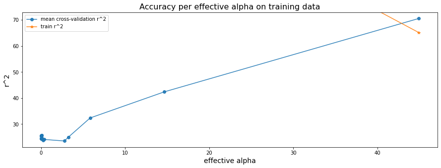

```python
plot_cross_validation_on_regression_trees(alphas, sm_cv_scores_mean, sm_cv_scores_std, sm_accuracy_scores,
                               'Accuracy per effective alpha on training data')
```

```python
best_score_loc = np.where(sm_cv_scores_mean == np.amin(sm_cv_scores_mean))[0][0]
cv_alpha = alphas[best_score_loc]
```

```python
clf = DecisionTreeRegressor(random_state=0, ccp_alpha=cv_alpha)
clf.fit(X_train, y_train)
```

```
DecisionTreeRegressor(ccp_alpha=2.7517275252745614, random_state=0)
```

```python
clf.tree_.max_depth
```

```
4
```

```python
test_predictions = clf.predict(X_test)
```

```python
mean_squared_error(y_test,test_predictions)
```

```
21.736485750732154
```

Using cross-validation with cost complexity tuning, I found a regression tree of max depth 4 had a test mean squared error of 21.7, less than the original (full decision tree) test mean squared error of 27.

# Exercise 9

```python
OJ = pd.read_csv('OJ.csv')
```

```python
OJ['Store7'] = OJ.Store7.map(dict(Yes=1, No=0))
```

```python
OJ.head()
```

|  | Purchase | WeekofPurchase | StoreID | PriceCH | PriceMM | DiscCH | DiscMM | SpecialCH | SpecialMM | LoyalCH | SalePriceMM | SalePriceCH | PriceDiff | Store7 | PctDiscMM | PctDiscCH | ListPriceDiff | STORE |
| --- | --- | --- | --- | --- | --- | --- | --- | --- | --- | --- | --- | --- | --- | --- | --- | --- | --- | --- |
| 0 | CH | 237 | 1 | 1.75 | 1.99 | 0.00 | 0.0 | 0 | 0 | 0.500000 | 1.99 | 1.75 | 0.24 | 0 | 0.000000 | 0.000000 | 0.24 | 1 |
| 1 | CH | 239 | 1 | 1.75 | 1.99 | 0.00 | 0.3 | 0 | 1 | 0.600000 | 1.69 | 1.75 | -0.06 | 0 | 0.150754 | 0.000000 | 0.24 | 1 |
| 2 | CH | 245 | 1 | 1.86 | 2.09 | 0.17 | 0.0 | 0 | 0 | 0.680000 | 2.09 | 1.69 | 0.40 | 0 | 0.000000 | 0.091398 | 0.23 | 1 |
| 3 | MM | 227 | 1 | 1.69 | 1.69 | 0.00 | 0.0 | 0 | 0 | 0.400000 | 1.69 | 1.69 | 0.00 | 0 | 0.000000 | 0.000000 | 0.00 | 1 |
| 4 | CH | 228 | 7 | 1.69 | 1.69 | 0.00 | 0.0 | 0 | 0 | 0.956535 | 1.69 | 1.69 | 0.00 | 1 | 0.000000 | 0.000000 | 0.00 | 0 |

## 9a) training set with 800 observations

```python
oj_input_cols = list(OJ.columns)
oj_input_cols.remove('Purchase')
```

```python
X = OJ[oj_input_cols]
y = OJ['Purchase']
```

```python
# Split into Test and Training data
X_train, X_test, y_train, y_test = train_test_split(X, y, train_size=800, random_state=42)
```

## 9 b) Fit tree to training data

```python
clf = tree.DecisionTreeClassifier()
clf = clf.fit(X_train,y_train)
```

```python
train_predictions = clf.predict(X_train)
```

```python
print(classification_report(y_train,train_predictions))
```

```
              precision    recall  f1-score   support

          CH       0.99      1.00      0.99       494
          MM       0.99      0.99      0.99       306

    accuracy                           0.99       800
   macro avg       0.99      0.99      0.99       800
weighted avg       0.99      0.99      0.99       800
```

```python
1-accuracy_score(y_train,train_predictions)
```

```
0.007499999999999951
```

```python
clf.get_depth()
```

```
16
```

```python
clf.tree_.node_count
```

```
325
```

The training error rate of the tree is 0.007, with a max depth of 16 and node count of 325.

## 9 c/d) Detailed tree output/ Plot of the tree

```python
dot_data = tree.export_graphviz(clf, out_file=None,
                               feature_names=X.columns,
                               class_names=y.unique(),
                               filled=True, rounded=True,
                               special_characters=True)
graph = graphviz.Source(dot_data)
graph
```

[figure not shown]

The baseline classification decision tree in scikit-learn created nodes until each terminal node gini value was as small as possible. So in this case there were many terminal nodes with only a few samples in each. Therefor the information in each of these nodes shows the gini coefficient (typically 0 in this tree), the number of samples, and the class. This is likely an over fit.

## 9 e) Predict response on test data

```python
test_predictions = clf.predict(X_test)
```

```python
print(classification_report(y_test,test_predictions))
```

```
              precision    recall  f1-score   support

          CH       0.75      0.78      0.77       159
          MM       0.67      0.63      0.65       111

    accuracy                           0.72       270
   macro avg       0.71      0.71      0.71       270
weighted avg       0.72      0.72      0.72       270
```

```python
1-accuracy_score(y_test,test_predictions)
```

```
0.28148148148148144
```

```python
results = confusion_matrix(y_test, test_predictions)
```

```python
df_cm = pd.DataFrame(results, index=['CH','MM'], columns = ['CH','MM'])
df_cm
```

|  | CH | MM |
| --- | --- | --- |
| CH | 124 | 35 |
| MM | 41 | 70 |

The test error rate is 0.28.

## 9f) Apply cross validation to training set in order to determine optimal tree size

```python
path = clf.cost_complexity_pruning_path(X_train,y_train)
ccp_alphas, impurities = path.ccp_alphas, path.impurities
```

```python
clfs = []
tree_node_count = []
max_depth = []
error_rate = []
for ccp_alpha in ccp_alphas:
    clf = DecisionTreeClassifier(random_state=0, ccp_alpha=ccp_alpha)
    clf.fit(X_train, y_train)
    clfs.append(clf)
    test_predictions = clf.predict(X_test)
    error_rate.append(1-accuracy_score(y_test,test_predictions))
    tree_node_count.append(clf.tree_.node_count)
    max_depth.append(clf.tree_.max_depth)
cost_complexity_dict = {'alpha_eff':ccp_alphas,'node_count':tree_node_count, 'max_depth':max_depth, 'error_rate': error_rate}
```

```python
cost_complexity_df = pd.DataFrame(cost_complexity_dict)
cost_complexity_df
```

|  | alpha_eff | node_count | max_depth | error_rate |
| --- | --- | --- | --- | --- |
| 0 | 0.000000 | 323 | 16 | 0.285185 |
| 1 | 0.000417 | 317 | 16 | 0.285185 |
| 2 | 0.000417 | 317 | 16 | 0.285185 |
| 3 | 0.000417 | 317 | 16 | 0.285185 |
| 4 | 0.000417 | 315 | 16 | 0.285185 |
| ... | ... | ... | ... | ... |
| 69 | 0.006779 | 9 | 3 | 0.192593 |
| 70 | 0.013851 | 9 | 3 | 0.192593 |
| 71 | 0.018721 | 5 | 2 | 0.207407 |
| 72 | 0.022236 | 3 | 1 | 0.207407 |
| 73 | 0.169266 | 3 | 1 | 0.207407 |

74 rows × 4 columns

```python
# Figure out alpha values for each max_depth
alphas = []
for depth in cost_complexity_df.max_depth.unique():
    df = cost_complexity_df.loc[cost_complexity_df['max_depth'] == depth]
    min_id = df['error_rate'].idxmin()
    alpha_eff = df.loc[min_id]['alpha_eff']
    alphas.append(alpha_eff)
if not alphas.count(0):
    alphas.insert(0,0)
```

```python
alphas
```

```
[0,
 0.0012313432835820883,
 0.0014285714285714284,
 0.0014508928571428572,
 0.0017633928571428575,
 0.0028084997439836116,
 0.003686079545454546,
 0.006597346201628912,
 0.018721052146869824,
 0.022236193710375746]
```

```python
sm_cv_scores_mean, sm_cv_scores_std, sm_accuracy_scores = run_cross_validation_on_trees(X_train, y_train, alphas)
```

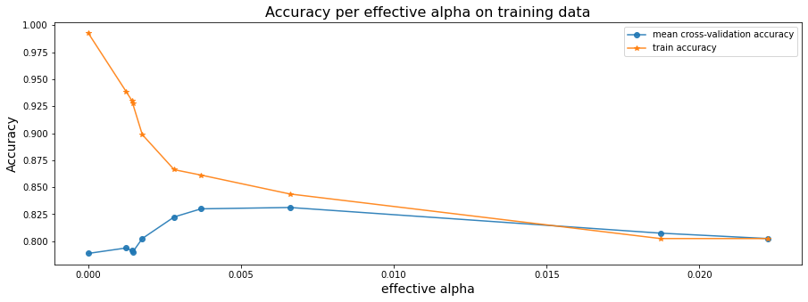

```python
plot_cross_validation_on_trees(alphas, sm_cv_scores_mean, sm_cv_scores_std, sm_accuracy_scores,
                               'Accuracy per effective alpha on training data')
```

```python
best_score_loc = np.where(sm_cv_scores_mean == np.amax(sm_cv_scores_mean))[0][0]
cv_alpha = ccp_alphas[best_score_loc]
cv_alpha
```

```
0.0006666666666666668
```

```python
clf = DecisionTreeClassifier(random_state=0, ccp_alpha=cv_alpha)
clf.fit(X_train, y_train)
```

```
DecisionTreeClassifier(ccp_alpha=0.0006666666666666668, random_state=0)
```

```python
clf.tree_.max_depth
```

```
16
```

```python
clf.tree_.node_count
```

```
297
```

```python
test_predictions = clf.predict(X_test)
```

```python
print(classification_report(y_test,test_predictions))
```

```
              precision    recall  f1-score   support

          CH       0.75      0.77      0.76       159
          MM       0.66      0.64      0.65       111

    accuracy                           0.72       270
   macro avg       0.71      0.71      0.71       270
weighted avg       0.72      0.72      0.72       270
```

```python
accuracy_score(y_test,test_predictions)
```

```
0.7185185185185186
```

```python
results = confusion_matrix(y_test, test_predictions)
```

```python
df_cm = pd.DataFrame(results, index=['No','Yes'], columns = ['No','Yes'])
df_cm
```

|  | No | Yes |
| --- | --- | --- |
| No | 123 | 36 |
| Yes | 40 | 71 |